# source2drive2R

Brooks Ambrose

December 17, 2015

# 1 Introduction

These instructions will allow you to access CTAWG plain text file data stored on bDrive via the Google Drive API.

## 1.1 Install

You only need to install once.

```r
install.packages("devtools")
install.packages("httr")
library(devtools)
install_github("RGoogleDrive", "1beb")
```

## 1.2 Load packages

```r
library(RGoogleDrive)
library(httr)
```

`RGoogleDrive` may throw a warning saying you will not be able to authenticate; these options are empty now but that will be taken care of later.

# 2 Authentication with Google Drive SDK

The [RGoogleDrive repo](https://github.com/1beb/RGoogleDrive) provides a helpful introduction to the problem of importing data from Drive into an R session. The function wrappers also provide a great example of a workflow. Unfortunately `RGoogleDrive` is designed to import only Google Docs and Sheets, where we need to import plain text, which will require us to write a custom wrapper (see below).

The first step, however is the same. It is necessary to create a Google App that can manage credentials for accessing the Google Drive API through a particular user account. As the `RGoogleDrive` repo explains:

> *RGoogleDrive*

> This R package is largely a wrapper for Hadley Wickham’s httr, built with the specific intention of providing access to the [Google Drive SDK](https://developers.google.com/drive/v2/reference/) from within R.

> Google’s updated API relies on OAuth 2.0 making it impossible to use simple authentication past the deprecation date of the first API (Scheduled for April 2015). This means that you must register your own app, with it’s own secret key.
> 1. Go to [Google’s API Console](https://cloud.google.com/console#/project)
> 2. Turn on the Google Drive SDK for that project and save the app url, and secret key

The **app url** and **secret key** are really what you need to get started, after making a careful choice about whose drive you want to provide R access to.

## 2.1 Setting up access to Drive though the Google Cloud

The process below has been completed by the Oski Bear `ctawg.dlab@gmail.com` user account; if you would like to replicate this process for your own data analysis project that uses Google Drive to store and serve data, follow along. While not very obvious it is certainly doable, in only 14 easy steps! For most of you in CTAWG, you may proceed to Step 11 by clicking on **Quick Start** in the table of contents above. You may execute the R code with credentials presented there, and then follow the remaining steps to authorize your R session to query the Oski Bear Drive.

*Step 1*: Choose a user that is happy to share access to her entire Google Drive account! Oski Bear is happy to oblige; we strongly advise against setting this up for your personal or work account, as you will be giving permission to access the *entire* contents of the Drive.

[figure not shown]

*Step 2*: While logged into the account that will be granting access, navigate to https://console.cloud.google.com and click **Select a Project** > **Create a project…**.

[figure not shown]

*Step 3*: Create a “project” which is also sometimes referred to as a Google App. Choose an ID – I chose CTAWG and the DLab’s zip code as the ID for the CTAWG file server app. Click create, then go back to the console which will now be displayed as a project dashboard. You should see your project name where it formerly said **Select a Project**. Further changes will now be applied to that project.

[figure not shown]

*Step 4*: From the project dashboard, click on **Enable APIs and get credentials like keys** or just **Enable APIs** depending on your view. The window should now say **API Manager** on the left. Scroll down until you see the **Google Drive API** and click on it.

[figure not shown]

*Step 5*: You will follow the **Accessing user data with OAuth 2.0** procedure. Study the diagram if you like to get a sense of what you’re doing–it feels like you’re hiring a security guard for your Drive except he’s happy to let anyone through who made a photocopy of your ID. Click **Enable API** at the top.

[figure not shown]

*Step 6*: You will be prompted to create credentials to allow access to the API. Click **Go to Credentials**.

[figure not shown]

*Step 7*: From the **Add credentials to your project** page, click **client ID** (don’t bother with the drop down menus)…

[figure not shown]

*Step 8*: …then click **Configure consent screen**.

[figure not shown]

*Step 9*: Now you can configure the screen that users will see when Oski Bear’s app asks permission to query your Drive contents. This will come up later, but it’s good to be reminded of the risk here. Oski will later have to giver herself permission, but anyone could accidentaly grant full access by clicking through too hastily, so be careful not to give it permission while logged into your personal or work account.

[figure not shown]

*Step 10*: It will now let you create the client ID. Here we treat the R wrapper as the client and give it the same name `source2drive2R`. Click **Create**.

[figure not shown]

# 3 Quick start

*Step 11*: Voilà! We finally have the credentials that `RGoogleDrive` requires to authenticate before we can access the drive.

[figure not shown]

Copy and paste the credentials as options for `RGoogleDrive` as follows. Note that because these credentials have already been created and because Oski Bear has granted permission to allow you to access her drive, you don’t have to go through most of this process; it was documented here merely for posterity.

```r
options(drive.app = "429378125165-h2j8q0qt1tjbonenhq26hudn8irrhtl2.apps.googleusercontent.com",
    drive.secret = "jtqnt-0omiQCXRVqUxwejVec")
```

*Step 12*: Now you can try to authenticate by entering the following R command.

```r
drive.auth()
```

The first time you do this the R console will present a link that you should copy and paste into a browser. Before pasting this link, be sure to be logged into the account whose Drive you wish to access.

> Again the Oski Bear account was created for this purpose (user: `ctawg.dlab`, password: `i<3textanalysis`) and we advise against you granting access to your own account unless you wish to serve your own project data to yourself.

When you paste the link you will be prompted to give permission to Oski Bear’s app. Click **Allow**.

[figure not shown]

*Step 13*: You will be given a confirmation code that must be copied and pasted without quotes and entered at the R prompt. When prompted we suggest that you choose to store your token locally, otherwise you may need to repeat this process.

[figure not shown]

*Step 14*: If all goes well, you should see something like this in your R console.

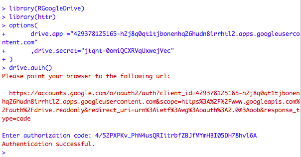

Congrats! You’re ready to query the CTAWG Congressional text data.

# 4 Query and download

```r
#' A wrapper to *httr* and *RGoogleDrive* to query and download from an already authenticated Google Drive user account
#' @param title.search Character vector of regular expressions to search for plain text file titles uploaded to Drive. Do not include the '.txt' extension, and only .txt files will be returned. All matching results will be saved in a list named according to each search term.
#' @param icpsr A logical indicating whether the text are the icpsr delimited database text files. If TRUE, will convert the text into an R data.table.
source2drive2R.f <- function(title.search = c("SpeakerID", "GPOdescr", "GPOspeech"),
    icpsr = T) {
    require(data.table)
    require(httr)
    require(RGoogleDrive)
    raw.list <- GET("https://www.googleapis.com/drive/v2/files?maxResults=100000",
        config(token = getOption("drive.auth")))
    parsed.list <- content(raw.list, as = "parsed")
    all.files <- sapply(parsed.list$items, function(x) x$title, simplify = F)
    icpsr.files <- sapply(paste(title.search, ".*\\.txt$", sep = ""), function(x) grep(x,
        all.files, value = T), simplify = F)
    icpsr.w <- sapply(paste(title.search, ".*\\.txt$", sep = ""), function(x) grep(x,
        all.files, value = F), simplify = F)
    ret <- list()
    for (i in names(icpsr.w)) for (j in 1:length(icpsr.files[[i]])) {
        filesize <- paste(round(as.integer(parsed.list$items[[icpsr.w[[i]][j]]]$fileSize)/(2^20),
            3), "MB")
        cat(c("\nDownloading ", filesize, " \"", icpsr.files[[i]][j], "\""),
            sep = "")
        t0 <- proc.time()
        ret[[i]][icpsr.files[[i]][j]] <- list(content(GET(parsed.list$items[[icpsr.w[[i]][j]]]$downloadUrl,
            config(token = getOption("drive.auth"))), as = "text"))
        t1 <- proc.time()
        cat("\nDownloaded in", round((t1 - t0)[3]/60, 2), "minutes.")
        if (icpsr) {
            cat("\nConverting ICPSR text file to data.table.")
            ret[[i]][icpsr.files[[i]][j]] <- strsplit(ret[[i]][[icpsr.files[[i]][j]]],
                split = "\r\n")
            cols <- strsplit(ret[[i]][[icpsr.files[[i]][j]]][1], split = "\\|")[[1]]
            ret[[i]][icpsr.files[[i]][j]] <- list(do.call(rbind, strsplit(ret[[i]][[icpsr.files[[i]][j]]][-1],
                split = "\\|")))
            dim <- dim(ret[[i]][[icpsr.files[[i]][j]]])
            ret[[i]][icpsr.files[[i]][j]] <- list(data.table(data.frame(lapply(split(x = ret[[i]][[icpsr.files[[i]][j]]],
                f = rep(1:dim[2], each = dim[1])), type.convert))))
            setnames(ret[[i]][[icpsr.files[[i]][j]]], cols)
            ret[[i]][[icpsr.files[[i]][j]]][, `:=`(order, 1:nrow(ret[[i]][[icpsr.files[[i]][j]]]))]
            setkeyv(ret[[i]][[icpsr.files[[i]][j]]], colnames(ret[[i]][[icpsr.files[[i]][j]]])[1])
            cat(" Done.")
        }
        attr(ret[[i]][[icpsr.files[[i]][j]]], "source.file.size") <- filesize
    }
    ret
}
```

The wrapper takes two arguments. The first is a vector of regular expressions that will be search terms for text document titles stored in Drive. For each search term, all documents matching the regular expression will be stored in a list with the same name as the regular expression. The second argument tells the wrapper that the files being imported are ICPSR delimited databases. `icpsr=TRUE` will convert these databases to a `data.table`, a format that acts like a `data.frame` but will allow us to easily join text to covariates from keyed tables. `icpsr=FALSE` will store each imported document as a single character string that can be parsed further. By default, e.g. if you supply no arguments: `mydata<-source2drive2R.f()`, it will try to download all of the ICPSR data, which weighs more than a gigabyte.

Note that it may take several minutes to download large files (the transfer appears to be unusually slow, probably something to do with Google Cloud free tier features). The following chunk will download the covariate ‘descr’ file (12 MB) and full text (165 MB!) of the Congressional Record for the 107th Congress. If you save the file, note how much smaller the file size of the compressed `.RData` format is compared to the original files!

```r
test <- source2drive2R.f(c("GPOdescr_107", "GPOspeech_107"))
```

```
##
## Downloaded in 0.58 minutes.
## Converting ICPSR text file to data.table. Done.
## Downloaded in 7.5 minutes.
## Converting ICPSR text file to data.table. Done.
```

```r
save(test, file = "icpsr107.RData")
```

# 5 How to use the results

Notice the naming scheme.

```r
sapply(test, names)
```

```
##  GPOdescr_107.*\\.txt$ GPOspeech_107.*\\.txt$
##     "GPOdescr_107.txt"    "GPOspeech_107.txt"
```

```r
str(test)
```

```
## List of 2
##  $ GPOdescr_107.*\.txt$ :List of 1
##   ..$ GPOdescr_107.txt:Classes 'data.table' and 'data.frame':    145453 obs. of  11 variables:
##   .. ..$ speechID             : num [1:145453] 1.07e+13 1.07e+13 1.07e+13 1.07e+13 1.07e+13 ...
##   .. ..$ date                 : int [1:145453] 10103 10103 10103 10103 10103 10103 10103 10103 10103 10103 ...
##   .. ..$ num_order_within_file: int [1:145453] 1 2 3 1 1 1 2 3 4 5 ...
##   .. ..$ speakerID            : int [1:145453] 107900 107900 107900 107900 107900 107900 107400 107900 107486 107900 ...
##   .. ..$ file                 : Factor w/ 19212 levels "Hcr01au01-49 1.txt",..: 600 600 600 601 602 603 603 603 603 603 ...
##   .. ..$ line_start           : int [1:145453] 69 71 612 16 16 16 21 32 33 38 ...
##   .. ..$ line_end             : int [1:145453] 70 611 613 24 19 19 31 32 37 43 ...
##   .. ..$ page                 : Factor w/ 12268 levels "","     Helms",..: 7 7 7 937 937 939 939 939 939 939 ...
##   .. ..$ char count           : int [1:145453] 101 915 107 574 232 177 669 45 301 308 ...
##   .. ..$ word count           : int [1:145453] 18 144 16 92 40 31 112 7 51 45 ...
##   .. ..$ order                : int [1:145453] 1 2 3 4 5 6 7 8 9 10 ...
##   .. ..- attr(*, ".internal.selfref")=<externalptr>
##   .. ..- attr(*, "sorted")= chr "speechID"
##   .. ..- attr(*, "source.file.size")= chr "12.168 MB"
##  $ GPOspeech_107.*\.txt$:List of 1
##   ..$ GPOspeech_107.txt:Classes 'data.table' and 'data.frame':   145453 obs. of  3 variables:
##   .. ..$ speechID: num [1:145453] 1.07e+13 1.07e+13 1.07e+13 1.07e+13 1.07e+13 ...
##   .. ..$ speech  : Factor w/ 54134 levels "--and I fear the White House is now blocking the early adoption by the Senate of legislation that would create a Department of "| __truncated__,..: 47727 48235 31055 31078 31061 37133 37154 42684 37159 37458 ...
##   .. ..$ order   : int [1:145453] 1 2 3 4 5 6 7 8 9 10 ...
##   .. ..- attr(*, ".internal.selfref")=<externalptr>
##   .. ..- attr(*, "sorted")= chr "speechID"
##   .. ..- attr(*, "source.file.size")= chr "164.445 MB"
```

```r
test
```

```
## $`GPOdescr_107.*\\.txt$`
## $`GPOdescr_107.*\\.txt$`$GPOdescr_107.txt
##             speechID  date num_order_within_file speakerID
##      1: 1.072001e+13 10103                     1    107900
##      2: 1.072001e+13 10103                     2    107900
##      3: 1.072001e+13 10103                     3    107900
##      4: 1.072001e+13 10103                     1    107900
##      5: 1.072001e+13 10103                     1    107900
##     ---
## 145449: 1.072002e+13 21216                     3    107500
## 145450: 1.072002e+13 21216                     4    107300
## 145451: 1.072002e+13 21216                     5    107900
## 145452: 1.072002e+13 21216                     6    107300
## 145453: 1.072002e+13 21216                     7    107499
##                       file line_start line_end          page char count
```

[output cut: 63 more lines]